# Creating residual maps from linear regression

2023-10-04

1. Remove all objects from R workspace—good programming practice and can help debug your code better.

```r
rm(list = ls())
```

2. Load the “tidyr” package:

```r
library(tidyr)
```

3. Read the age adjusted 5-year rates of cancers across the USA. Extract lung cancer rates for California. Order the data by county names.

```r
rate_5y <- read.csv("data/age_adjusted.csv")
rate_CA = rate_5y[substr(rate_5y$State_county,1,2) == "CA",]
rate_lung = rate_CA[rate_CA$Site_recode_ICD_O_3_WHO_2008=="Lung and Bronchus",]
rate_lung = rate_lung[order(readr::parse_number(as.character(rate_lung$State_county))),]
```

4. We will need to extract county names from the database. First inspect the “State_county” variable to see the naming pattern.

```r
head(rate_lung)
```

```
##                      State_county Site_recode_ICD_O_3_WHO_2008
## 248    CA: Alameda County (06001)            Lung and Bronchus
## 1472    CA: Alpine County (06003)            Lung and Bronchus
## 1574    CA: Amador County (06005)            Lung and Bronchus
## 1676     CA: Butte County (06007)            Lung and Bronchus
## 1778 CA: Calaveras County (06009)            Lung and Bronchus
## 1880    CA: Colusa County (06011)            Lung and Bronchus
##      Age_Adjusted_Rate Count Population
## 248               41.5  3416    8041533
## 1472              22.0     2       5466
## 1574              59.6   209     185015
## 1676              57.9   849    1117709
## 1778              45.7   191     224439
## 1880              53.2    57     106940
```

```r
rate_lung$State_county
```

```
##  [1] "CA: Alameda County (06001)"         "CA: Alpine County (06003)"
##  [3] "CA: Amador County (06005)"          "CA: Butte County (06007)"
##  [5] "CA: Calaveras County (06009)"       "CA: Colusa County (06011)"
##  [7] "CA: Contra Costa County (06013)"    "CA: Del Norte County (06015)"
##  [9] "CA: El Dorado County (06017)"       "CA: Fresno County (06019)"
## [11] "CA: Glenn County (06021)"           "CA: Humboldt County (06023)"
## [13] "CA: Imperial County (06025)"        "CA: Inyo County (06027)"
## [15] "CA: Kern County (06029)"            "CA: Kings County (06031)"
## [17] "CA: Lake County (06033)"            "CA: Lassen County (06035)"
## [19] "CA: Los Angeles Registry (06037)"   "CA: Madera County (06039)"
## [21] "CA: Marin County (06041)"           "CA: Mariposa County (06043)"
## [23] "CA: Mendocino County (06045)"       "CA: Merced County (06047)"
## [25] "CA: Modoc County (06049)"           "CA: Mono County (06051)"
## [27] "CA: Monterey County (06053)"        "CA: Napa County (06055)"
## [29] "CA: Nevada County (06057)"          "CA: Orange County (06059)"
## [31] "CA: Placer County (06061)"          "CA: Plumas County (06063)"
## [33] "CA: Riverside County (06065)"       "CA: Sacramento County (06067)"
## [35] "CA: San Benito County (06069)"      "CA: San Bernardino County (06071)"
## [37] "CA: San Diego County (06073)"       "CA: San Francisco County (06075)"
## [39] "CA: San Joaquin County (06077)"     "CA: San Luis Obispo County (06079)"
## [41] "CA: San Mateo County (06081)"       "CA: Santa Barbara County (06083)"
## [43] "CA: Santa Clara County (06085)"     "CA: Santa Cruz County (06087)"
## [45] "CA: Shasta County (06089)"          "CA: Sierra County (06091)"
## [47] "CA: Siskiyou County (06093)"        "CA: Solano County (06095)"
## [49] "CA: Sonoma County (06097)"          "CA: Stanislaus County (06099)"
## [51] "CA: Sutter County (06101)"          "CA: Tehama County (06103)"
## [53] "CA: Trinity County (06105)"         "CA: Tulare County (06107)"
## [55] "CA: Tuolumne County (06109)"        "CA: Ventura County (06111)"
## [57] "CA: Yolo County (06113)"            "CA: Yuba County (06115)"
```

5. Get rid of “CA:” from the names

```r
rate_lung$State_county = sapply(strsplit(rate_lung$State_county, ":"), function(x) x[2])
```

6. Get rid of “County” inside the names

```r
rate_lung$State_county = sub("County", "", rate_lung$State_county)
```

7. Get rid of “Registry” inside the names (appears only for “Los Angeles”)

```r
rate_lung$State_county = sub("Registry", "", rate_lung$State_county)
```

8. Get rid of “the last 7 characters” from the names (they represent FIPS codes)

```r
rate_lung$State_county = substr(rate_lung$State_county, 1, nchar(rate_lung$State_county)-7)
```

9. Get rid of unnecessary white spaces

```r
rate_lung$State_county = trimws(rate_lung$State_county)
```

10. Rename “State_county” as simply “County”

```r
names(rate_lung)[names(rate_lung) == "State_county"] <- "County"
```

11. Remove row numbers from the data frame:

```r
row.names(rate_lung) <- NULL
```

This completes the creation of the dataframe “rate_lung”.

12. Read the data on smoking rates and inspect its column names.

```r
smoking <- read.csv("data/smoking.csv")
head(smoking)
```

```
##      County. Cigarette.Smoking.Rate.
## 1   Alameda                   11.5%
## 2    Alpine                   12.6%
## 3    Amador                   12.6%
## 4     Butte                   15.9%
## 5 Calaveras                   12.6%
## 6    Colusa                   18.9%
```

13. Rename its variables to “County” and “Smoking_Rate”

```r
names(smoking) <- c("County", "Smoking_Rate")
```

14. We will merge the “smoking” data frame with the rate_lung data frame by column “County”. It will be important to check for hidden whitespaces in this column for both data frames.

```r
smoking$County <- trimws(smoking$County, whitespace="[\t\r\n\\h\\v]")
```

15. Also make sure that Smoking_Rate is numeric

```r
smoking$Smoking_Rate <- as.numeric(trimws(sub("%", "", smoking$Smoking_Rate), whitespace="[\t\r\n\\h\\v]"))
```

16. Now we will merge the data into a single data frame

```r
rate_lung <- merge(rate_lung, smoking, by="County")
```

17. Our first model: Run a simple linear regression of “Age_Adjusted_Rate” on “Smoking_Rate”

```r
out.lm <- lm(Age_Adjusted_Rate ~ Smoking_Rate, data = rate_lung)
summary(out.lm)
```

```
##
## Call:
## lm(formula = Age_Adjusted_Rate ~ Smoking_Rate, data = rate_lung)
##
## Residuals:
##      Min       1Q   Median       3Q      Max
## -21.0928  -3.4639  -0.1371   5.1453  16.5072
##
## Coefficients:
##              Estimate Std. Error t value Pr(>|t|)
## (Intercept)   26.1161     3.4429   7.586 3.73e-10 ***
## Smoking_Rate   1.3474     0.2266   5.947 1.85e-07 ***
## ---
## Signif. codes:  0 '***' 0.001 '**' 0.01 '*' 0.05 '.' 0.1 ' ' 1
##
## Residual standard error: 7.354 on 56 degrees of freedom
## Multiple R-squared:  0.3871, Adjusted R-squared:  0.3761
## F-statistic: 35.37 on 1 and 56 DF,  p-value: 1.854e-07
```

18. Obtain the residuals from the linear regression model

```r
resid.lm <- residuals(out.lm)
```

19. Plot the residuals on a map: We know how to do this! Begin by loading some libraries.

```r
library(maps)
library(sf)
library(RColorBrewer)
library(dplyr)
library(tidyr)
library(classInt)
```

20. Get county map for California from R “maps” library and create an “sf” object.

```r
ca.county = map("county","california", fill=TRUE, plot=FALSE)
ca.county.sf <- st_as_sf(ca.county)
```

21. Expand the “sf” object to include the variable you wish to plot. Note that resid.lm is already ordered by county names so it will align.

```r
ca.county.sf$resid.lm <- resid.lm
```

22. Create a color palette.

```r
brks_resid.lm = quantile(ca.county.sf$resid.lm, c(0, 0.2, 0.4, 0.6, 0.8, 1))

color.palette = rev(brewer.pal(5,"RdBu"))
class(color.palette)
```

```
## [1] "character"
```

23. Plot the residuals on the map. What do you see?

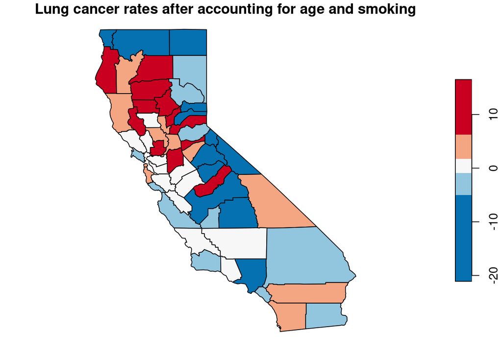

```r
plot(ca.county.sf["resid.lm"], pal = color.palette, breaks = brks_resid.lm, main = "Lung cancer rates after accounting for age and smoking")
```